# Hmk2

Github : https://github.com/t-aozy/Hmk2_STAT506/upload

## Problem 1 -Dice Game

## a. 4 Versions

### a.1 Version 1_loop

```r
#' play_dice_1
#' use loop to output the total winning points after several rolls
#' @param x total number of rolls
#' @param seed control randomness, default value is null
#' @return final winning points
play_dice_1 <- function(x, seed = NULL){

  winnings <- 0

  # if seed is not null, set seed
  if(is.null(seed) == FALSE){
    set.seed(seed)
  }
  # Randomly get x results from the 6-side dice
  numbers <- sample(1:6, x, replace = TRUE)
  for(i in 1:x){
    number <- numbers[i]
    if(number == 3 | number == 5){
      winnings <- winnings + number*2 - 2
    }else{
      winnings <- winnings - 2
    }
  }
  return(winnings)

}
```

### a.2 Version 2_using built-in R vectorized functions

I use ifelse(), sum() two verctorized functions to form the function.

```r
#' play_dice_2
#' use ifelse, sum to output the total winning points after several rolls
#' @param x total number of rolls
#' @param seed control randomness, default value is null
#' @return final winning points
play_dice_2 <- function(x, seed = NULL){
  # if seed is not null, set seed
  if(is.null(seed) == FALSE){
    set.seed(seed)
  }
  numbers <- sample(1:6, x, replace = TRUE)
  winning_each <- ifelse((numbers == 3 | numbers == 5), numbers*2-2, -2)
  return( sum(winning_each))
}
```

### a.3 Version 3_using table()

```r
#' play_dice_3
#' @param x total number of rolls
#' @param seed control randomness
#' @return final winning points
play_dice_3 <- function(x, seed = NULL){
  # if seed is not null , set seed
  if(is.null(seed)==FALSE){
    set.seed(seed)
  }
  numbers <- sample(1:6, x, replace = TRUE)

  # use table
  ta <- table(numbers)
  winning_points <- 0
  for(i in 1:length(ta)){
    if(names(ta)[i] %in% c("1", "2", "4", "6")){
      winning_points <- winning_points-2*ta[i]
    }
    else{
      winning_points <- winning_points+(as.integer(names(ta)[i])*2-2)*ta[i]
    }
  }
  return(winning_points)
}
```

### a.4 Version 4_ apply()

```r
#' apply_funct
#' function to apply towawrd each roll, if the number of dice is 3/5, return
#' winning points (2*3/5) - cost for each round (-2)
#' @param x roll number
#' @return winning points for a specific round
apply_funct <- function(x){
  if(x == 3 | x == 5){
    return (2*x-2)
  }else{
    return (-2)
  }
}
#' play_dice_4
#' use mapply() to output the total winning points after several rolls
#' @param x total number of rolls
#' @param seed control randomness, default value is null
#' @return final winning points
play_dice_4 <- function(x, seed = NULL){
  # generate roll results
  if(is.null(seed) == FALSE){
    set.seed(seed)
  }
  numbers <- sample(1:6, x, replace = TRUE)

  # use apply
  apply_num <- mapply(apply_funct, numbers)
  return (sum(apply_num))

}
```

## b. Demonstrate all versions work

For each 3-roll games and 3000-roll games of version1 to version4, I repeated 100 times, for the 3-roll games result, I used table() to show the distribution of the results; For the3000-roll game result, I used histogram.

### b.1 Version 1

```r
table(mapply(play_dice_1, rep(3, 100)))
```

```
-6  0  4  6 10 12 14 16 20
37 21 19  5 11  1  1  2  3
```

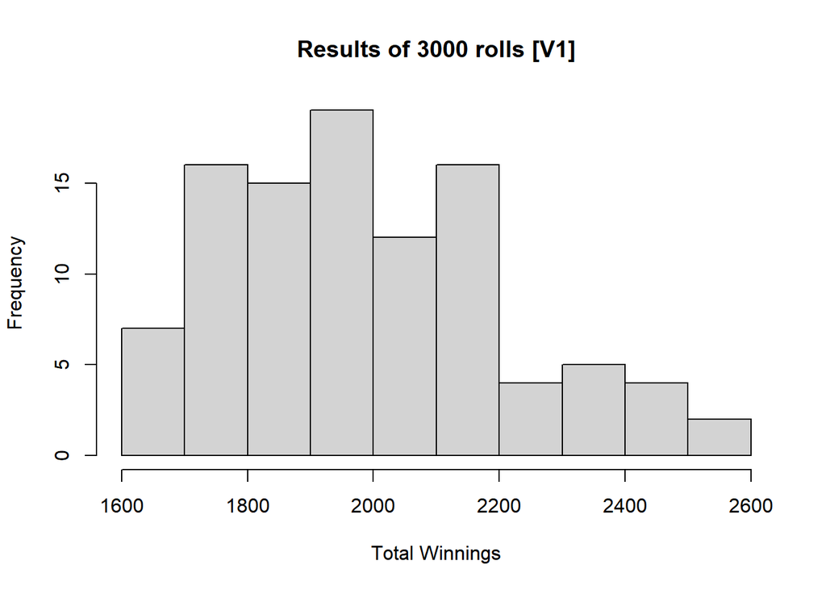

```r
hist(mapply(play_dice_1, rep(3000, 100)),
     main = "Results of 3000 rolls [V1]",
     xlab = "Total Winnings")
```

### b.2 Version 2

```r
table(mapply(play_dice_2, rep(3, 100)))
```

```
-6  0  4  6 10 14 16 24
31 24 17  9 10  6  2  1
```

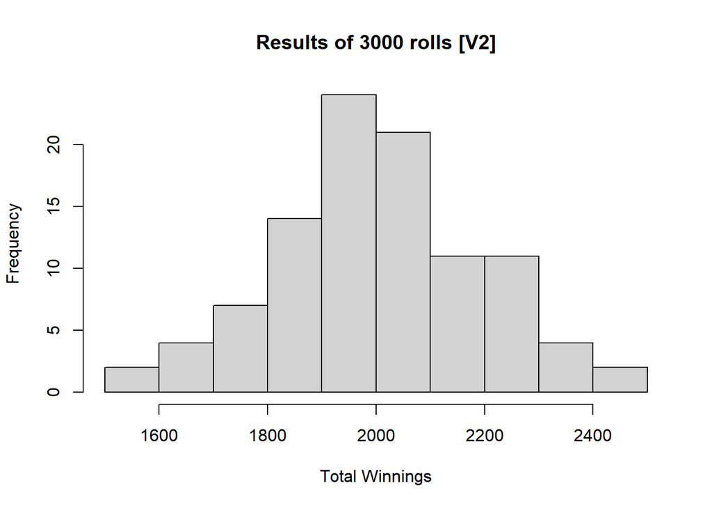

```r
hist(mapply(play_dice_2, rep(3000, 100)),
     main = "Results of 3000 rolls [V2]",
     xlab = "Total Winnings")
```

### b.3 Version 3

```r
table(mapply(play_dice_3, rep(3, 100)))
```

```
-6  0  4  6 10 12 14 16 20
22 20 27  5  9  1 14  1  1
```

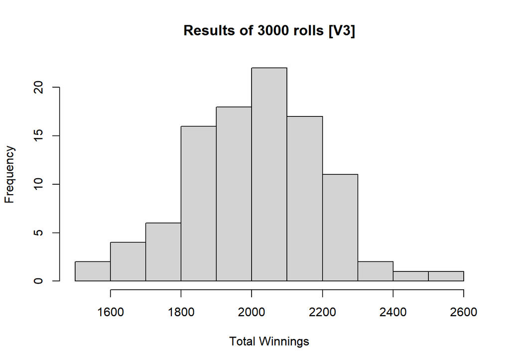

```r
hist(mapply(play_dice_4, rep(3000, 100)),
     main = "Results of 3000 rolls [V3]",
     xlab = "Total Winnings")
```

### b.4 Version 4

```r
table(mapply(play_dice_4, rep(3, 100)))
```

```
-6  0  4  6 10 14 16 20
29 17 20  8 14  7  3  2
```

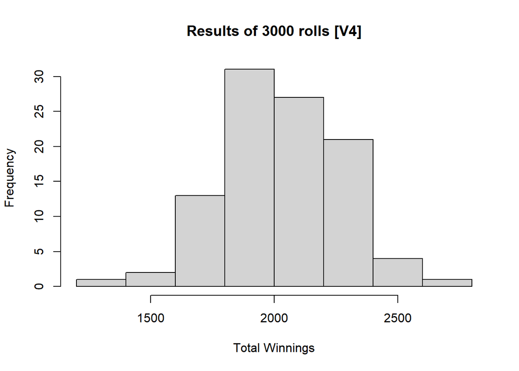

```r
hist(mapply(play_dice_4, rep(3000, 100)),
     main = "Results of 3000 rolls [V4]",
     xlab = "Total Winnings")
```

## c. Demonstrate that the four versions give the same result.

Seed is used to control randomization.

I used 6 seeds : 1001, 1002, 1003, 1004, 1005, 1006 to test the consistence of the results. According to the result, we know that the four versions give the same result.

### c.1 Test with 3 rolls

```r
for(seed in 1001:1006){
  cat(
    "Set seed = ", seed, "\n",
    "Result of Version 1:", play_dice_1(3, seed), "\n",
    "Result of Version 2:", play_dice_2(3, seed), "\n",
    "Result of Version 3:", play_dice_3(3, seed), "\n",
    "Result of Version 4:", play_dice_4(3, seed), "\n",
    "\n"
  )
}
```

```
Set seed =  1001
 Result of Version 1: 6
 Result of Version 2: 6
 Result of Version 3: 6
 Result of Version 4: 6

Set seed =  1002
 Result of Version 1: 4
 Result of Version 2: 4
 Result of Version 3: 4
 Result of Version 4: 4

Set seed =  1003
 Result of Version 1: 4
 Result of Version 2: 4
 Result of Version 3: 4
 Result of Version 4: 4

Set seed =  1004
 Result of Version 1: 0
 Result of Version 2: 0
 Result of Version 3: 0
 Result of Version 4: 0

Set seed =  1005
 Result of Version 1: -6
 Result of Version 2: -6
 Result of Version 3: -6
 Result of Version 4: -6

Set seed =  1006
 Result of Version 1: 4
 Result of Version 2: 4
 Result of Version 3: 4
 Result of Version 4: 4
```

### c.2 Test with 3000 rolls

```r
for(seed in 1001:1006){
  cat(
    "Set seed = ", seed, "\n",
    "Result of Version 1:", play_dice_1(3000, seed), "\n",
    "Result of Version 2:", play_dice_2(3000, seed), "\n",
    "Result of Version 3:", play_dice_3(3000, seed), "\n",
    "Result of Version 4:", play_dice_4(3000, seed), "\n",
    "\n"
  )
}
```

```
Set seed =  1001
 Result of Version 1: 2110
 Result of Version 2: 2110
 Result of Version 3: 2110
 Result of Version 4: 2110

Set seed =  1002
 Result of Version 1: 1824
 Result of Version 2: 1824
 Result of Version 3: 1824
 Result of Version 4: 1824

Set seed =  1003
 Result of Version 1: 2120
 Result of Version 2: 2120
 Result of Version 3: 2120
 Result of Version 4: 2120

Set seed =  1004
 Result of Version 1: 2070
 Result of Version 2: 2070
 Result of Version 3: 2070
 Result of Version 4: 2070

Set seed =  1005
 Result of Version 1: 1978
 Result of Version 2: 1978
 Result of Version 3: 1978
 Result of Version 4: 1978

Set seed =  1006
 Result of Version 1: 1944
 Result of Version 2: 1944
 Result of Version 3: 1944
 Result of Version 4: 1944
```

## d. microbenchmark

### d.1 1000 rolls

```r
library(DT)
library(microbenchmark)
microbenchmark(
    play_dice_1(1000),
    play_dice_2(1000),
    play_dice_3(1000),
    play_dice_4(1000)
  )
```

```
Unit: microseconds
              expr     min       lq      mean   median       uq      max neval
 play_dice_1(1000) 128.801 149.1005 205.15504 178.6015 212.7510 1907.001   100
 play_dice_2(1000)  64.900  82.3010  99.40403  90.4010 108.7510  233.702   100
 play_dice_3(1000) 126.901 173.8015 245.36108 207.9010 287.9020 1964.401   100
 play_dice_4(1000) 509.801 574.7515 757.81804 695.8505 923.5015 1384.401   100
```

### d.2 100000 rolls

```r
microbenchmark(
  play_dice_1(100000),
  play_dice_2(100000),
  play_dice_3(100000),
  play_dice_4(100000)
)
```

```
Unit: milliseconds
               expr       min        lq       mean     median        uq
 play_dice_1(1e+05) 13.949900 19.954901  26.589035  24.783800  31.18860
 play_dice_2(1e+05)  6.124901  7.781301   9.738755   9.039200  10.22425
 play_dice_3(1e+05)  6.916401  8.231801  10.017512   9.403751  11.19110
 play_dice_4(1e+05) 69.210901 94.003100 129.170712 112.747601 156.57110
      max neval
  70.4925   100
  76.2189   100
  19.1427   100
 310.1390   100
```

According to the microbenchmark result, we learned that when there is a low input, there is not so much differences in terms of running time compare to a large input. However, we could still discover that version2, which uses built-in R vectorized functions has the fastest running speed, this is the same when the input is big, showing that vectorized function could increase the speed by operating in the compiled language C. Second, when the input is small, our result shows that using a loop(Version 1) is faster than using table()(Version 3), however, when the input increase, using table() is significantly faster than using a loop, this is because table() decreases the length of the loop when the input is large. Third, when using apply(), we gets the lowest running speed both in small input and large input, this is probably because that apply family actually contain implicit loops and it also takes time to call apply functions.

## e. Fair Game

If this is a fair game, no matter how many rolls the player choose, the probability of winning more than $0 should be around 0.5. Thus, I choose 1 roll game to 50 rolls game, simulated each game 10000 times, and show the estimated probability of winning more than $0 for each game. According to our simulation, as the number of rolls increases, the proportion of winning more than $0 quickly exceed 0.5. Therefore, this is not a fair game.

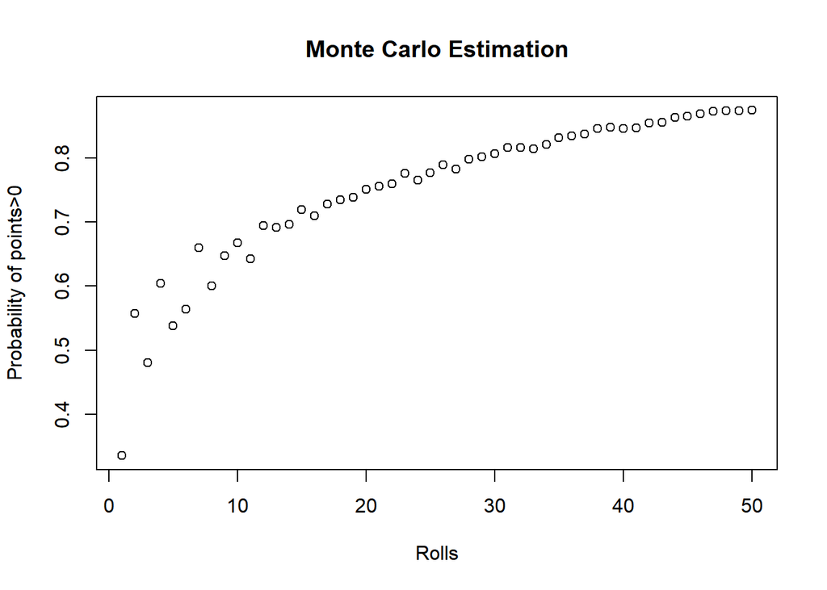

```r
#' prob
#' @param x a vector that contains winning points of 10000 rounds of a n-roll game
#' @return probability/proportion that winning points >0
prob <- function(x){
  nrow1 <- length(x[x>0])
  nrow2 <- length(x)
  return (nrow1/nrow2)
}



# build test dataset, from 1-roll game to 50-roll game, each repeat 10000 times.
test_set <- rep(1:50, each = 10000)
test_res <- mapply(play_dice_2, test_set)

# form a data frame
res <- data.frame(cbind(test_set, test_res))
names(res) <- c("rolls", "points")
plot(tapply(res$points, res$rolls, prob),
     xlab = "Rolls", ylab = "Probability of points>0",
     main = "Monte Carlo Estimation")
```

# Problem 2 -Linear Regresson

## a. Import and rename columns

```r
# load data
data <- read.csv("D:/cars.csv")
names(data) <- c("height", "length", "width", "driveline", "engine_type",
                 "hybrid", "gears", "transmission", "city_mpg", "fuel",
                 "highway_mpg", "classification", "id", "make", "year_model",
                 "year_release", "horsepower", "torque")
datatable(data)
```

|  | height | length | width | driveline | engine_type | hybrid | gears | transmission | city_mpg | fuel | highway_mpg | classification | id | make | year_model | year_release | horsepower | torque |
| --- | --- | --- | --- | --- | --- | --- | --- | --- | --- | --- | --- | --- | --- | --- | --- | --- | --- | --- |
| 1 | 140 | 143 | 202 | All-wheel drive | Audi 3.2L 6 cylinder 250hp 236ft-lbs | True | 6 | 6 Speed Automatic Select Shift | 18 | Gasoline | 25 | Automatic transmission | 2009 Audi A3 3.2 | Audi | 2009 Audi A3 | 2009 | 250 | 236 |
| 2 | 140 | 143 | 202 | Front-wheel drive | Audi 2.0L 4 cylinder 200 hp 207 ft-lbs Turbo | True | 6 | 6 Speed Automatic Select Shift | 22 | Gasoline | 28 | Automatic transmission | 2009 Audi A3 2.0 T AT | Audi | 2009 Audi A3 | 2009 | 200 | 207 |
| 3 | 140 | 143 | 202 | Front-wheel drive | Audi 2.0L 4 cylinder 200 hp 207 ft-lbs Turbo | True | 6 | 6 Speed Manual | 21 | Gasoline | 30 | Manual transmission | 2009 Audi A3 2.0 T | Audi | 2009 Audi A3 | 2009 | 200 | 207 |
| 4 | 140 | 143 | 202 | All-wheel drive | Audi 2.0L 4 cylinder 200 hp 207 ft-lbs Turbo | True | 6 | 6 Speed Automatic Select Shift | 21 | Gasoline | 28 | Automatic transmission | 2009 Audi A3 2.0 T Quattro | Audi | 2009 Audi A3 | 2009 | 200 | 207 |
| 5 | 140 | 143 | 202 | All-wheel drive | Audi 2.0L 4 cylinder 200 hp 207 ft-lbs Turbo | True | 6 | 6 Speed Automatic Select Shift | 21 | Gasoline | 28 | Automatic transmission | 2009 Audi A3 2.0 T Quattro | Audi | 2009 Audi A3 | 2009 | 200 | 207 |
| 6 | 91 | 17 | 62 | All-wheel drive | Audi 3.2L 6 cylinder 265hp 243 ft-lbs | True | 6 | 6 Speed Manual | 16 | Gasoline | 27 | Manual transmission | 2009 Audi A5 3.2 | Audi | 2009 Audi A5 | 2009 | 265 | 243 |
| 7 | 91 | 17 | 62 | All-wheel drive | Audi 3.2L 6 cylinder 265hp 243 ft-lbs | True | 6 | 6 Speed Automatic Select Shift | 17 | Gasoline | 26 | Automatic transmission | 2009 Audi A5 3.2 AT | Audi | 2009 Audi A5 | 2009 | 265 | 243 |
| 8 | 201 | 221 | 191 | All-wheel drive | Audi 4.2L 8 cylinder 350 hp 325 ft-lbs | True | 6 | 6 Speed Automatic Select Shift | 13 | Gasoline | 18 | Automatic transmission | 2009 Audi Q7 4.2 | Audi | 2009 Audi Q7 | 2009 | 350 | 325 |
| 9 | 201 | 221 | 191 | All-wheel drive | Audi 3.6L 6 cylinder 280hp 266 ft-lbs | True | 6 | 6 Speed Automatic Select Shift | 14 | Gasoline | 20 | Automatic transmission | 2009 Audi Q7 3.6 | Audi | 2009 Audi Q7 | 2009 | 280 | 266 |
| 10 | 147 | 96 | 34 | All-wheel drive | Audi 2.0L 4 cylinder 211 hp 258 ft-lbs Turbo | True | 6 | 6 Speed Manual | 22 | Gasoline | 30 | Manual transmission | 2009 Audi A4 Sedan 2.0 T Quattro | Audi | 2009 Audi A4 Sedan | 2009 | 211 | 258 |

[output cut: 5066 more lines]

## b. Restrict data

After data restriction, we get 4591 rows.

```r
data <- data[data$fuel == "Gasoline",]
datatable(data)
```

|  | height | length | width | driveline | engine_type | hybrid | gears | transmission | city_mpg | fuel | highway_mpg | classification | id | make | year_model | year_release | horsepower | torque |
| --- | --- | --- | --- | --- | --- | --- | --- | --- | --- | --- | --- | --- | --- | --- | --- | --- | --- | --- |
| 1 | 140 | 143 | 202 | All-wheel drive | Audi 3.2L 6 cylinder 250hp 236ft-lbs | True | 6 | 6 Speed Automatic Select Shift | 18 | Gasoline | 25 | Automatic transmission | 2009 Audi A3 3.2 | Audi | 2009 Audi A3 | 2009 | 250 | 236 |
| 2 | 140 | 143 | 202 | Front-wheel drive | Audi 2.0L 4 cylinder 200 hp 207 ft-lbs Turbo | True | 6 | 6 Speed Automatic Select Shift | 22 | Gasoline | 28 | Automatic transmission | 2009 Audi A3 2.0 T AT | Audi | 2009 Audi A3 | 2009 | 200 | 207 |
| 3 | 140 | 143 | 202 | Front-wheel drive | Audi 2.0L 4 cylinder 200 hp 207 ft-lbs Turbo | True | 6 | 6 Speed Manual | 21 | Gasoline | 30 | Manual transmission | 2009 Audi A3 2.0 T | Audi | 2009 Audi A3 | 2009 | 200 | 207 |
| 4 | 140 | 143 | 202 | All-wheel drive | Audi 2.0L 4 cylinder 200 hp 207 ft-lbs Turbo | True | 6 | 6 Speed Automatic Select Shift | 21 | Gasoline | 28 | Automatic transmission | 2009 Audi A3 2.0 T Quattro | Audi | 2009 Audi A3 | 2009 | 200 | 207 |
| 5 | 140 | 143 | 202 | All-wheel drive | Audi 2.0L 4 cylinder 200 hp 207 ft-lbs Turbo | True | 6 | 6 Speed Automatic Select Shift | 21 | Gasoline | 28 | Automatic transmission | 2009 Audi A3 2.0 T Quattro | Audi | 2009 Audi A3 | 2009 | 200 | 207 |
| 6 | 91 | 17 | 62 | All-wheel drive | Audi 3.2L 6 cylinder 265hp 243 ft-lbs | True | 6 | 6 Speed Manual | 16 | Gasoline | 27 | Manual transmission | 2009 Audi A5 3.2 | Audi | 2009 Audi A5 | 2009 | 265 | 243 |
| 7 | 91 | 17 | 62 | All-wheel drive | Audi 3.2L 6 cylinder 265hp 243 ft-lbs | True | 6 | 6 Speed Automatic Select Shift | 17 | Gasoline | 26 | Automatic transmission | 2009 Audi A5 3.2 AT | Audi | 2009 Audi A5 | 2009 | 265 | 243 |
| 8 | 201 | 221 | 191 | All-wheel drive | Audi 4.2L 8 cylinder 350 hp 325 ft-lbs | True | 6 | 6 Speed Automatic Select Shift | 13 | Gasoline | 18 | Automatic transmission | 2009 Audi Q7 4.2 | Audi | 2009 Audi Q7 | 2009 | 350 | 325 |
| 9 | 201 | 221 | 191 | All-wheel drive | Audi 3.6L 6 cylinder 280hp 266 ft-lbs | True | 6 | 6 Speed Automatic Select Shift | 14 | Gasoline | 20 | Automatic transmission | 2009 Audi Q7 3.6 | Audi | 2009 Audi Q7 | 2009 | 280 | 266 |
| 10 | 147 | 96 | 34 | All-wheel drive | Audi 2.0L 4 cylinder 211 hp 258 ft-lbs Turbo | True | 6 | 6 Speed Manual | 22 | Gasoline | 30 | Manual transmission | 2009 Audi A4 Sedan 2.0 T Quattro | Audi | 2009 Audi A4 Sedan | 2009 | 211 | 258 |

[output cut: 4581 more lines]

## c. Distribution

I first use scatter plot to check whether the relationship between toque and highway gas mileage is linear, by checking the distribution of highway gas mileage, it seems that the data points do not locate on a line, so I choose log transformation, as is shown in the second plot, when I get log value of both toque and highway_mpg, the relation seems linear.

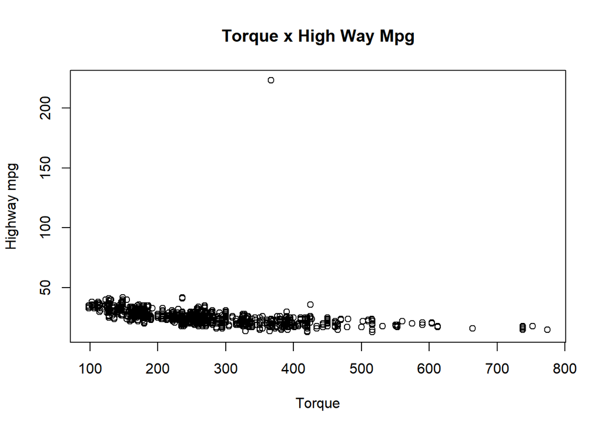

```r
# show the relationship between highway_mpg and torque
plot(x = data$torque, y = data$highway_mpg, xlab = "Torque",
     ylab = "Highway mpg", main = "Torque x High Way Mpg")
```

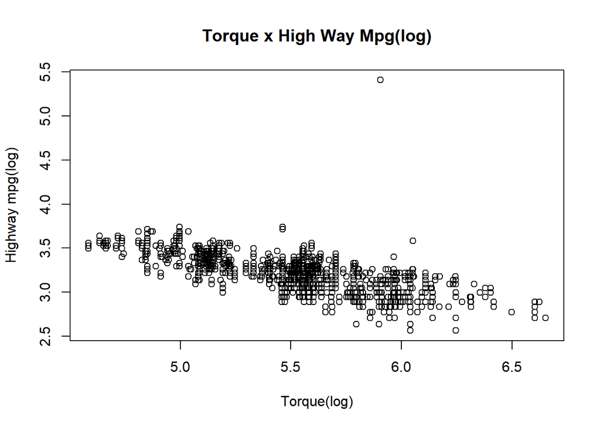

```r
# transformation
data$log_torque <- mapply(log, data$torque)
data$log_highway_mpg <- mapply(log, data$highway_mpg)
plot(x = data$log_torque, y = data$log_highway_mpg, xlab = "Torque(log)",
     ylab = "Highway mpg(log)", main = "Torque x High Way Mpg(log)")
```

## d. Fit models

From the result of c, I choose log value of MPG on the highway and also log value of torque.

According to the regression result, the relationship of torque and MPG on the highway can be interpreted as:

For two cars with the same height, length, width, horsepower and release year, when the torque of the engine in one car improved by 1% , the expected distance the car can cover per gallen on highways is estimated to be 0.67% less than the other. A 1% increase in torque is associated with -0.67% increase in highway mpg.

```r
# turen release year variable into factor
data$year_release <- as.factor(data$year_release)

# build the predicting model
model <- log_highway_mpg ~ log_torque + horsepower + height +
                        length + width + year_release

# show the result
summary(lm(model, data))
```

```
Call:
lm(formula = model, data = data)

Residuals:
     Min       1Q   Median       3Q      Max
-0.55482 -0.08226 -0.00753  0.08082  2.44055

Coefficients:
                   Estimate Std. Error t value Pr(>|t|)
(Intercept)       6.586e+00  6.602e-02  99.745  < 2e-16 ***
log_torque       -6.714e-01  1.385e-02 -48.477  < 2e-16 ***
horsepower        1.101e-03  5.389e-05  20.428  < 2e-16 ***
height            2.509e-04  3.170e-05   7.915 3.09e-15 ***
length            2.011e-05  2.465e-05   0.816   0.4146
width            -1.806e-04  2.449e-05  -7.373 1.98e-13 ***
year_release2010 -1.754e-02  1.888e-02  -0.929   0.3529
year_release2011 -9.480e-04  1.885e-02  -0.050   0.9599
year_release2012  4.126e-02  1.900e-02   2.172   0.0299 *
---
Signif. codes:  0 '***' 0.001 '**' 0.01 '*' 0.05 '.' 0.1 ' ' 1

Residual standard error: 0.1284 on 4582 degrees of freedom
Multiple R-squared:  0.6391,    Adjusted R-squared:  0.6385
F-statistic:  1014 on 8 and 4582 DF,  p-value: < 2.2e-16
```

## e. Interaction between torque and highway MPG

```r
summary(data$torque)
```

```
   Min. 1st Qu.  Median    Mean 3rd Qu.    Max.
   98.0   177.0   257.0   267.2   332.0   774.0
```

```r
summary(data$horsepower)
```

```
   Min. 1st Qu.  Median    Mean 3rd Qu.    Max.
  100.0   185.0   263.0   267.5   317.0   638.0
```

The refitted model is shown below.

```r
# new fitted model
model_inter <- highway_mpg ~ torque*horsepower + height +
                        length + width + year_release

# regression result
summary(lm(model_inter, data = data))
```

```
Call:
lm(formula = model_inter, data = data)

Residuals:
    Min      1Q  Median      3Q     Max
-11.109  -2.313  -0.258   2.062 203.540

Coefficients:
                    Estimate Std. Error t value Pr(>|t|)
(Intercept)        4.219e+01  7.930e-01  53.199  < 2e-16 ***
torque            -8.606e-02  2.533e-03 -33.972  < 2e-16 ***
horsepower        -1.666e-02  2.539e-03  -6.563 5.84e-11 ***
height             6.560e-03  1.070e-03   6.133 9.32e-10 ***
length             1.777e-03  8.318e-04   2.136   0.0327 *
width             -1.169e-03  8.521e-04  -1.372   0.1700
year_release2010  -5.628e-01  6.372e-01  -0.883   0.3771
year_release2011   7.254e-02  6.361e-01   0.114   0.9092
year_release2012   1.197e+00  6.411e-01   1.867   0.0619 .
torque:horsepower  1.124e-04  4.628e-06  24.276  < 2e-16 ***
---
Signif. codes:  0 '***' 0.001 '**' 0.01 '*' 0.05 '.' 0.1 ' ' 1

Residual standard error: 4.333 on 4581 degrees of freedom
Multiple R-squared:  0.4854,    Adjusted R-squared:  0.4844
F-statistic: 480.1 on 9 and 4581 DF,  p-value: < 2.2e-16
```

The interaction plot is shown below, according to the plot and both the regression result above, keeping all the other variables equal , when torque improve by 1 lb/feet, cars with greater horsepower will get a less decrease in the mpg on highways.

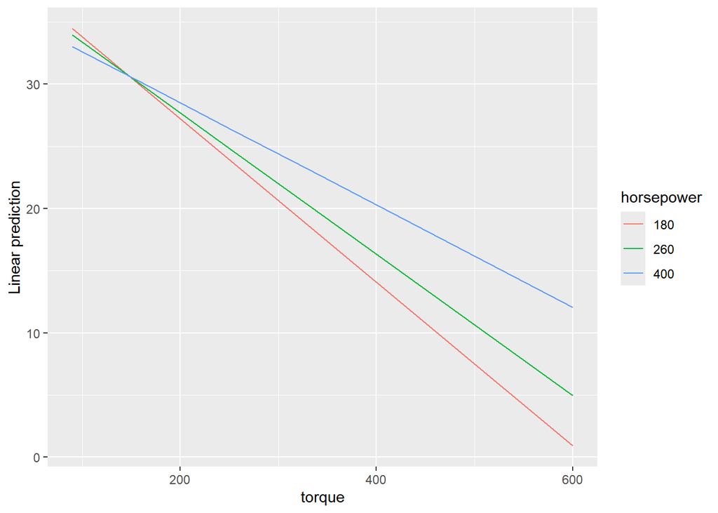

```r
# interaction plot
library(emmeans)
emmip(lm(model_inter, data = data),
      horsepower ~ torque,
      at = list(horsepower = c(180, 260, 400),
                torque = c(90, 170, 255, 330, 600)))
```

```r
summary(data$log_torque)
```

```
   Min. 1st Qu.  Median    Mean 3rd Qu.    Max.
  4.585   5.176   5.549   5.517   5.805   6.652
```

```r
model_inter_1 <- log_highway_mpg ~ log_torque*horsepower + height +
                        length + width + year_release

summary(lm(model_inter, data))
```

```
Call:
lm(formula = model_inter, data = data)

Residuals:
    Min      1Q  Median      3Q     Max
-11.109  -2.313  -0.258   2.062 203.540

Coefficients:
                    Estimate Std. Error t value Pr(>|t|)
(Intercept)        4.219e+01  7.930e-01  53.199  < 2e-16 ***
torque            -8.606e-02  2.533e-03 -33.972  < 2e-16 ***
horsepower        -1.666e-02  2.539e-03  -6.563 5.84e-11 ***
height             6.560e-03  1.070e-03   6.133 9.32e-10 ***
length             1.777e-03  8.318e-04   2.136   0.0327 *
width             -1.169e-03  8.521e-04  -1.372   0.1700
year_release2010  -5.628e-01  6.372e-01  -0.883   0.3771
year_release2011   7.254e-02  6.361e-01   0.114   0.9092
year_release2012   1.197e+00  6.411e-01   1.867   0.0619 .
torque:horsepower  1.124e-04  4.628e-06  24.276  < 2e-16 ***
---
Signif. codes:  0 '***' 0.001 '**' 0.01 '*' 0.05 '.' 0.1 ' ' 1

Residual standard error: 4.333 on 4581 degrees of freedom
Multiple R-squared:  0.4854,    Adjusted R-squared:  0.4844
F-statistic: 480.1 on 9 and 4581 DF,  p-value: < 2.2e-16
```

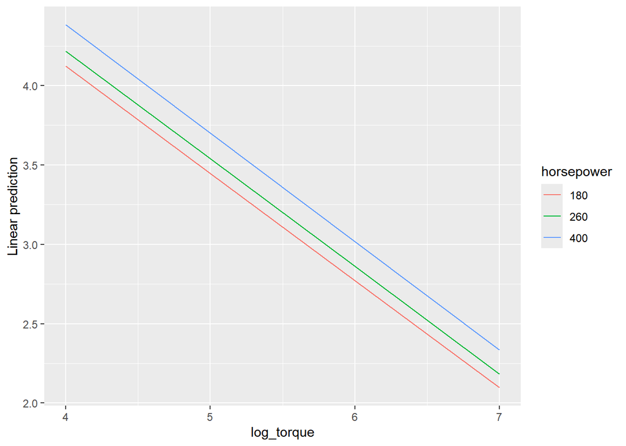

```r
emmip(lm(model_inter_1, data = data),
      horsepower ~ log_torque,
      at = list(horsepower = c(180, 260, 400),
                log_torque = c(4, 5, 6, 7)))
```

## f. Manually calculate

As is shown below, we have same result with that in d.

```r
# generate the design matrix
X <- model.matrix(model, data = data)

# extract y values
y <- data$log_highway_mpg

# calculate estimates of beta
beta_hat <- solve(t(X)%*%X)%*%t(X)%*%y
beta_hat
```

```
                          [,1]
(Intercept)       6.585633e+00
log_torque       -6.714102e-01
horsepower        1.100786e-03
height            2.509278e-04
length            2.010719e-05
width            -1.805810e-04
year_release2010 -1.754184e-02
year_release2011 -9.479497e-04
year_release2012  4.126178e-02
```